# Tutorial04_luel8892

## 2 think+type: moons of Jupiter

```python
#declaring the list moons with some of juipters moons
```

```python
moons = ["Io", "Europa", "Ganymede", "Callisto"] #some of the jovian moons

periods = [42.5, 85.2, 171.7, 400.5] #the periods of the above jovian moons in hours

orbit_sizes = [ 111, 178, 282, 499] # the rough size of each orbit in arcseconds

initial_phases = [2.542, 3.739, 5.831, 1.669] # the initial orbital phases of the jovian the moons, in radians
```

```python
print(moons) #printing the list, moons

print(periods) #printing the periods of the moons

print(orbit_sizes) #printing the size of each moons orbit

print(initial_phases) #printing the phases of each moon
```

```
['Io', 'Europa', 'Ganymede', 'Callisto']
[42.5, 85.2, 171.7, 400.5]
[111, 178, 282, 499]
[2.542, 3.739, 5.831, 1.669]
```

## 3 think+type: printing lists

```python
print("moon             period         orbit size            intial phase")
for i in range(len(moons)):   #since all the list are the same length, I will do this that way in the future I could add more moons with thier relative information
    print(f"{moons[i]:10} {periods[i]:10} {orbit_size[i]:13} {initial_phases[i]:23}")
```

```
moon             period         orbit size            intial phase
Io               42.5           111                   2.542
Europa           85.2           178                   3.739
Ganymede        171.7           282                   5.831
Callisto        400.5           499                   1.669
```

## 4 think+code: being flexible

well, oops, it appears I accidentally already did this step. In the code I wrote for section 3, I preemptively changed the for loop conditions. The given condition was for i in range(4):, I was thinking that in the future I could add more jovian moons so I changed the for loop parameter to for i in range(len(moons)) this will allow me to add more jovian moons as long as I also add each aditional moons period, orbital size and initial phase to the other list respectively.

```python
#same code with my modification of the for loop condition
print("moon             period         orbit size            intial phase")
for i in range(len(moons)):   #since all the list are the same length, I will do this that way in the future I could add more moons with thier relative information
    print(f"{moons[i]:10} {periods[i]:10} {orbit_size[i]:13} {initial_phases[i]:23}")
```

```
moon             period         orbit size            intial phase
Io               42.5           111                   2.542
Europa           85.2           178                   3.739
Ganymede        171.7           282                   5.831
Callisto        400.5           499                   1.669
```

## 5 think+type: zip()

```python
print("moon            period    orbit size  initial phase")
for m, p, o, i in zip(moons, periods, orbit_sizes, initial_phases): # testing out the zip function to print different element from different livraries without using a for loop
    print(f'{m:10} {p:10.1f} {o:10.0f} {i:10.3f}')
```

```
moon            period    orbit size  initial phase
Io               42.5        111      2.542
Europa           85.2        178      3.739
Ganymede        171.7        282      5.831
Callisto        400.5        499      1.669
```

## 6 think+pair+code: where are the moons?

I left class before I could work on this with a partner so this is just my code

x(t) = (A)sin((2(pi)t)/P + theta) formula for projected positon x(t0\) A = orbit size of the Jovian moon in arcseconds P is the orbital period of the Jovian moon in hours theta is the intial phase of the jovian moon in radians

```python
from math import sin, pi #importing what I need from the math library

t= 36.4

moon_pos = ["the project positions of the jovain moons at,", t, "hours  are,"] #creating a blank list for all of the moon's positions
#creating a for loop to calculate each moon's position at time t = 36.4 hours

for moon, P, A, theta in zip(moons, periods, orbit_sizes, initial_phases):
    t - 36.4 #hours
    x = A*sin((2*pi*t)/P+theta) #x(t) using the variable from the for loop
    moon_pos.append(moon) #adding the name of the moon to the moon_pos list
    moon_pos.append("is at, ")
    moon_pos.append(f"{x:0.2f}") #adding the rounded position of the moon
    moon_pos.append(",")
print(*moon_pos) #printing the list without brackets between each element
```

```
the project positions of the jovain moons at, 36.4 hours  are, Io is at,  110.73 , Europa is at,  24.87 , Ganymede is at,  217.32 , Callisto is at,  391.36 ,
```

## 7 think+type: define a helpful function

```python
import sys
sys.path.append('/home/taak5361/astr2600/shared/')
```

```python
import galileo

from galileo import drawMoons
```

```
---------------------------------------------------------------------------
ImportError                               Traceback (most recent call last)
Cell In[135], line 3
      1 import galileo
----> 3 from galileo import drawMoons

ImportError: cannot import name 'drawMoons' from 'galileo' (/home/luel8892/ASTR 2600/Tutorial/galileo.py)
```

I tried for a while to get this working by looking up how to import files into python and then downloading the galileo.py file

```python
import sys
sys.path.append('C:\Users\Lucae\Downloa"ds')
```

```
  Cell In[137], line 2
    sys.path.append('C:\Users\Lucae\Downloa"ds')
                                               ^
SyntaxError: (unicode error) 'unicodeescape' codec can't decode bytes in position 2-3: truncated \UXXXXXXXX escape
```

Tryubg to import the file from downloads using its path is also not workingso my plan is just to insert the code from galileo directly into this jupyter notebook

```python
#copying galileo.pu and pasting it below
import numpy as np
import matplotlib.pyplot as plt
def drawMoons(names, xpositions, xlim=[-500,500], labels=False, color=False):
    '''
    Draw a plot of the positions of moons relative to Jupiter.

    This function requires two input arguments. They should
    both be lists, and they should be the same size as each
    other. They are:

        moons -- a 1-dimensional list of moon names
        xpositions -- a 1-dimensional list of moon positions (in arcsec)

    For example:

        %matplotlib inline
        names = ['Io', 'Europa', 'Ganymede', 'Callisto']
        xpositions = [-20, 40, 80, -160]
        drawMoons(names, xpositions)

        (should display a plot of the moon positions)

    Options keyword arguments

        xlim = [-500,500]
            (set this to some other 2-element list to change
                the range over which the plot stretchs)
        labels = False
            (set this to True to provide text labels)
        color = False
            (set this to True to provide different colors for each moon)

    '''

    # since we're plotting only 1D positions, we make up y-values
    ypositions = np.zeros_like(xpositions)

    # we create a new figure, and set its size
    plt.figure(figsize=(10,.25))

    # if color output, set colors
    if color:
        colors=['orange','blue','magenta','green']
    else:
        colors=['black']*len(xpositions)

    # we plot the moons in their positions
    for i in range(len(xpositions)):
        plt.plot(xpositions[i], ypositions[i],
                    marker = '.',
                    linewidth=0,
                    color=colors[i])

    # if desired, we add text labels to all the moons
    if labels:
        for x, y, n in zip(xpositions, ypositions, names):
            plt.text(x, y+0.1, n, ha='center', va='bottom')

    # plot Jupiter in the center
    plt.plot(0,0, marker='o', markersize=10, color='black')

    # set the x and y limits of the plot
    plt.xlim(*xlim)
    plt.ylim(-1,1)

    # turn off all axis labels (and the box around the plot)
    plt.axis('off')

    # make sure the plot shows to the screen
    plt.show()
```

```python
help(drawMoons)
```

```
Help on function drawMoons in module __main__:

drawMoons(names, xpositions, xlim=[-500, 500], labels=False, color=False)
    Draw a plot of the positions of moons relative to Jupiter.

    This function requires two input arguments. They should
    both be lists, and they should be the same size as each
    other. They are:

        moons -- a 1-dimensional list of moon names
        xpositions -- a 1-dimensional list of moon positions (in arcsec)

    For example:

        %matplotlib inline
        names = ['Io', 'Europa', 'Ganymede', 'Callisto']
        xpositions = [-20, 40, 80, -160]
        drawMoons(names, xpositions)

        (should display a plot of the moon positions)

    Options keyword arguments

        xlim = [-500,500]
            (set this to some other 2-element list to change
                the range over which the plot stretchs)
        labels = False
            (set this to True to provide text labels)
        color = False
            (set this to True to provide different colors for each moon)
```

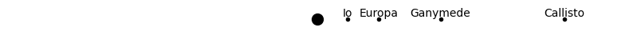

```python
drawMoons(moons, [50, 100, 200, 400], labels=True) #testing the drawMoons function
```

[output not shown]

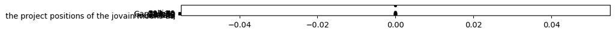

```python
drawMoons(moons, moon_pos, labels=True)
#tryin the drawMoons function with my current list moon_pos
```

MY moon_pos list conatins the moons positoin as well as strrings laveling each moon so I will need to define a new list with just their positions

```python
#defining my new list, moon_positions
moon_positions = []

for moon, P, A, theta in zip(moons, periods, orbit_sizes, initial_phases):
    t - 36.4 #hours
    x = A*sin((2*pi*t)/P+theta) #x(t) using the variable from the for loop
    y = int(x) # to make the data type accepted by the drawMoon function, I need to convert the floats to integers
    moon_positions.append(y)
print(moon_positions)
```

```
[110, 24, 217, 391]
```

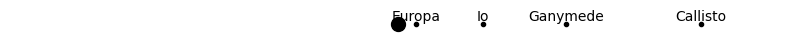

```python
drawMoons(moons, moon_positions, labels=True)
```

```python
moon_positions = [110, -171, 217, 391] #manually redfing the list moon_ppsition with the corrected data for europa

print(moon_positions)
```

```
[110, -171, 217, 391]
```

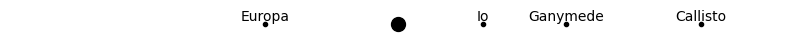

```python
drawMoons(moons, moon_positions, labels=True)
```

## 8 think+type+code: calculate the moon positions over time

to calculate the moon's positions over time, we will first need to create an increasing time counter variable to use in a while loop

```python
timer = 0
while(timer <= 500):
    print(timer)
    timer += 100
```

```
0
100
200
300
400
500
```

now I will replace t in my orginal code with timer

```python
timer = 0

#recreating the while loop I used to calculate each position
while(timer <= 500):
    moon_pos = []

    for moon, P, A, theta in zip(moons, periods, orbit_sizes, initial_phases):
        x = int(A*sin((2*pi*timer)/P+theta)) #x(t) using the variable from the for loop
        moon_pos.append(moon) #adding the name of the moon to the moon_pos list
        moon_pos.append("is at, ")
        moon_pos.append(x) #adding the rounded position of the moon
        moon_pos.append(",")
    timer += 100
    print(*moon_pos, "at time =", timer)
```

```
Io is at,  62 , Europa is at,  -100 , Ganymede is at,  -123 , Callisto is at,  496 , at time = 100
Io is at,  -110 , Europa is at,  -176 , Ganymede is at,  -18 , Callisto is at,  -47 , at time = 200
Io is at,  70 , Europa is at,  -62 , Ganymede is at,  155 , Callisto is at,  -496 , at time = 300
Io is at,  25 , Europa is at,  118 , Ganymede is at,  -251 , Callisto is at,  46 , at time = 400
Io is at,  -101 , Europa is at,  172 , Ganymede is at,  281 , Callisto is at,  496 , at time = 500
Io is at,  97 , Europa is at,  40 , Ganymede is at,  -238 , Callisto is at,  -44 , at time = 600
```

```python
timer = 0

#recreating the while loop I used to calculate each position
while(timer <= 500):
    moon_pos = []

    #simplifiting my for loop to only return the bare essentials
    for moon, P, A, theta in zip(moons, periods, orbit_sizes, initial_phases):
        x = int(A*sin((2*pi*timer)/P+theta)) #x(t) using the variable from the for loop
        moon_pos.append(x) #adding the rounded position of the moon
    timer += 100
    print(*moon_pos, "at time =", timer)
```

```
62 -100 -123 496 at time = 100
-110 -176 -18 -47 at time = 200
70 -62 155 -496 at time = 300
25 118 -251 46 at time = 400
-101 172 281 496 at time = 500
97 40 -238 -44 at time = 600
```

```
at time = 25 this is hwere the moons are:
```

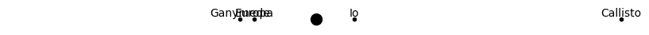

```
at time = 50 this is hwere the moons are:
```

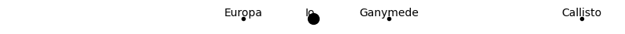

```
at time = 75 this is hwere the moons are:
```

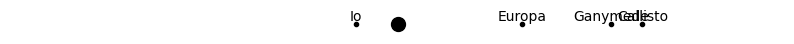

```
at time = 100 this is hwere the moons are:
```

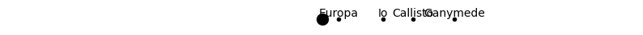

```
at time = 125 this is hwere the moons are:
```

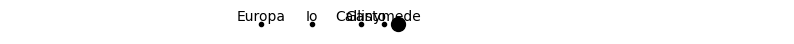

```
at time = 150 this is hwere the moons are:
```

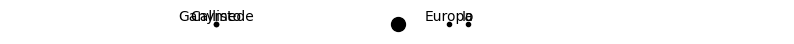

```
at time = 175 this is hwere the moons are:
```

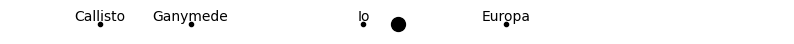

```
at time = 200 this is hwere the moons are:
```

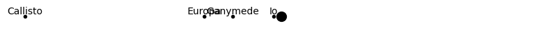

```
at time = 225 this is hwere the moons are:
```

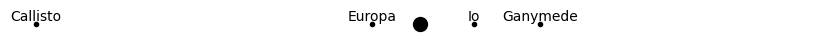

```
at time = 250 this is hwere the moons are:
```

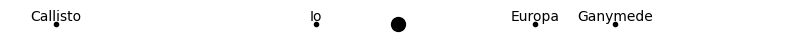

```
at time = 275 this is hwere the moons are:
```

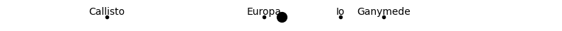

```
at time = 300 this is hwere the moons are:
```

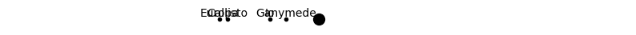

```
at time = 325 this is hwere the moons are:
```

[9 more figures not shown]

```python
timer = 0

#recreating the while loop I used to calculate each position
while(timer <= 500):
    moon_pos = []

    #simplifiting my for loop to only return the bare essentials
    for moon, P, A, theta in zip(moons, periods, orbit_sizes, initial_phases):
        x = int(A*sin((2*pi*timer)/P+theta)) #x(t) using the variable from the for loop
        moon_pos.append(x) #adding the rounded position of the moon
    timer += 25
    print("at time =", timer, "this is hwere the moons are:")
    drawMoons(moons, moon_pos, labels=True)
```

Please know that I now realize my initial results for the use of the drawing function were correct. I was confused because I thought that the moons should be in order of their distance away from Jupiter. However, this will not always happen because the drawing is one-dimensional while the moons' orbits are 3 dimensonal. This leads to times when, from the observer's perspective, the moons look out of order. However, they are not out of order. The majority of their orbital distance is just in a perpendicular dimension with the screen. While the drawings O have generated look somewhat random, they are not, and if you decrease the rate at which the timer is increased, then you will see that they are not random and do represent the Jupiter, four-moon system.

## 9 think+write: lists within a list

1 At the end of the code in [214], the length of moon_pos list is the same as it has been throughout the whole run. The moon_pos list remains a constant 4 integer long list the whole time. Every run through the while loop, the list is reset to a blank list and then filled with the four moons' positions

2 The length of the moon_pos list has no relationship with the number of times the code has been run, as the length of the moon_pos list is constantly 4

4 the list moon_pos[1] is differnt from moon_pos[0] as it represents the position of the second moon